# DSM-5008-Sunum

Buse Demir, Ezgi Yılmaz, Najibeh Mirinezhad, Yasin Sarıyıldız

11 04 2022

# VERİ SETİNİN TANITILMASI

#### Veri Seti Linki: (http://kaggle.com/code/dikshabhati2002/k-means-and-hierarchical-clustering/data)

```
## # A tibble: 6 x 9
##   child_mort exports health imports income inflation life_expec total_fer  gdpp
##        <dbl>   <dbl>  <dbl>   <dbl>  <dbl>     <dbl>      <dbl>     <dbl> <dbl>
## 1       90.2    10     7.58    44.9   1610      9.44       56.2      5.82   553
## 2       16.6    28     6.55    48.6   9930      4.49       76.3      1.65  4090
## 3       27.3    38.4   4.17    31.4  12900     16.1        76.5      2.89  4460
## 4      119      62.3   2.85    42.9   5900     22.4        60.1      6.16  3530
## 5       10.3    45.5   6.03    58.9  19100      1.44       76.8      2.13 12200
## 6       14.5    18.9   8.1     16    18700     20.9        75.8      2.37 10300
```

#### –> Yukarıda ilk 6 gözlem değeri verilen veri seti 167 satır 10 sütundan oluşmaktadır ve bazı ülkelere ait sosyo-ekonomik verileri ve sağlık verilerini içermektedir.Bu özelliklere bakılarak bir yardım kuruluşu (Help International) tarafından toplanan 10 milyon doların ihtiyacı olan ülkelere dağıtılması için bir strateji belirlenmek istenmektedir.

#### *child_mort* : 1000 doğumda 5 yaş altı çocukların ölümü

#### *exports*: Kişi başına mal ve hizmet ihracatı. Kişi başına düşen GSYİH’ı yüzde olarak verilir

#### *inflation*: Toplam GSYİH’nın yıllık büyüme oranının ölçümü

#### *life_expec*: Mevcut ölüm oranları aynı kalacaksa, yeni doğan bir çocuğun yaşayacağı ortalama yıl sayısı

# 2) TANIMLAYICI İSTATİSTİKLER

```
##    child_mort        exports            health          imports
##  Min.   :  2.60   Min.   :  0.109   Min.   : 1.810   Min.   :  0.0659
##  1st Qu.:  8.25   1st Qu.: 23.800   1st Qu.: 4.920   1st Qu.: 30.2000
##  Median : 19.30   Median : 35.000   Median : 6.320   Median : 43.3000
##  Mean   : 38.27   Mean   : 41.109   Mean   : 6.816   Mean   : 46.8902
##  3rd Qu.: 62.10   3rd Qu.: 51.350   3rd Qu.: 8.600   3rd Qu.: 58.7500
##  Max.   :208.00   Max.   :200.000   Max.   :17.900   Max.   :174.0000
##      income         inflation         life_expec      total_fer
##  Min.   :   609   Min.   : -4.210   Min.   :32.10   Min.   :1.150
##  1st Qu.:  3355   1st Qu.:  1.810   1st Qu.:65.30   1st Qu.:1.795
##  Median :  9960   Median :  5.390   Median :73.10   Median :2.410
##  Mean   : 17145   Mean   :  7.782   Mean   :70.56   Mean   :2.948
##  3rd Qu.: 22800   3rd Qu.: 10.750   3rd Qu.:76.80   3rd Qu.:3.880
##  Max.   :125000   Max.   :104.000   Max.   :82.80   Max.   :7.490
##       gdpp
##  Min.   :   231
##  1st Qu.:  1330
##  Median :  4660
##  Mean   : 12964
##  3rd Qu.: 14050
##  Max.   :105000
```

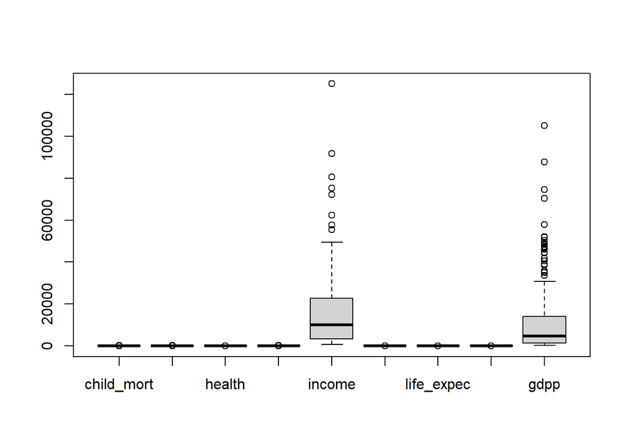

#### Değiskenlerin kutu grafiklerine ve *summary* değerlerine bakıldığında sapan değerler ve çarpık dağılımlar gözlemlenmiştir.

# Histogram Grafikleri

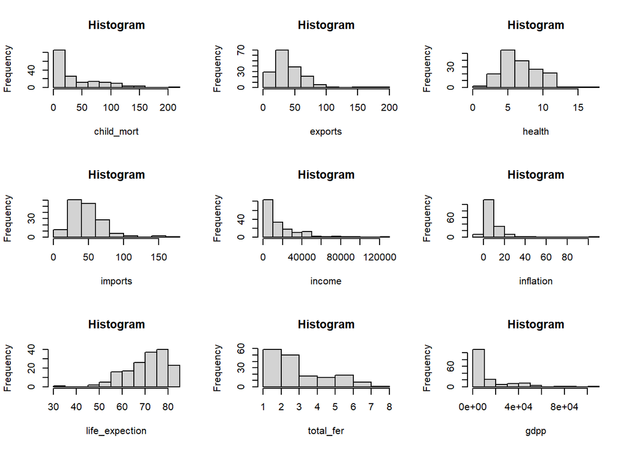

```
##   child_mort      exports       health      imports       income    inflation
##    40.328931    27.412010     2.746837    24.209589 19278.067698    10.570704
##   life_expec    total_fer         gdpp
##     8.893172     1.513848 18328.704809
```

```
##   child_mort      exports       health      imports       income    inflation
##    38.270060    41.108976     6.815689    46.890215 17144.688623     7.781832
##   life_expec    total_fer         gdpp
##    70.555689     2.947964 12964.155689
```

#### Histogram grafiklerine bakıldığında ise *child_mort*, *exports*,*imports*,*income*,*inflation*,*total_fer* ve *gdpp* değişkenleri sağa çarpık bir dağılıma sahipken *life_expec* değişkeni sola çarpık bir dağılıma sahiptir.

#### Değişkenlerin ortalamaları ve varyanlasları birbirinden oldukça farklı olduğu için korelasyon matrisi üzerinden PCA yapılmalıdır.

# Değişkenler Arasındaki İlişki

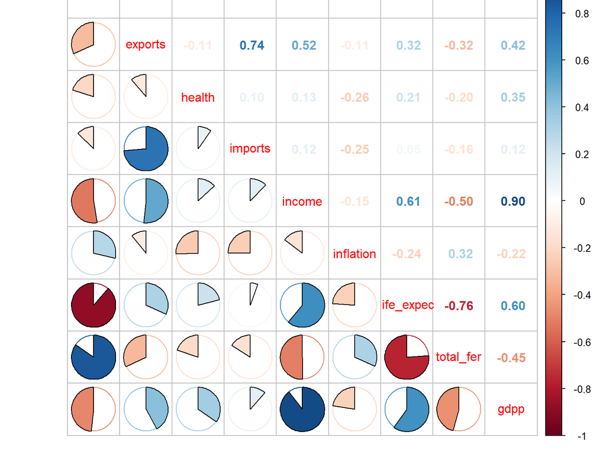

```r
corr <- cor(data, method = "pearson")
corrplot.mixed(corr, lower="pie",upper="number")
```

#### *child mort*(5 yaş altı çocukların ölümü) ile *life_expec*(yeni doğan bir çocuğun ortalama yaşam süresi) değişkenleri arasında (-1’e çok yakın olduğu için -0.89) negatif yönde güçlü doğrusal bir ilişki vardır. Yine *life_expec* ile *total_fer*(bir kadının doğacak çocuk sayısı) arasında (-1’e yakın olduğu için -0.76) ile negatif yönde doğrusal bir ilişki vardır. *income* ve *gdpp* arasında beklenildiği üzere (1’e çok yakın 0.9) ile pozitif yönde çok güçlü doğrusal bir ilişki varken *total_fer* ve *chil_mort* (0.85) ile *exports* ve *imports* (0.74) pozitif yönde korelasyonu yüksek değişkenlerdir. *export* ve *income* arasında ise orta düzeyde doğrusal bir ilişki vardır.(0.51)

# 3) PCA

### Özdeğerler

```
##                   [,1]      [,2]      [,3]      [,4]       [,5]       [,6]
## eigenvalues  4.1356566 1.5463463 1.1703833 0.9947846 0.66061903 0.22358112
## prop.var     0.4595174 0.1718163 0.1300426 0.1105316 0.07340211 0.02484235
## cum.prop.var 0.4595174 0.6313337 0.7613762 0.8719079 0.94530998 0.97015232
##                   [,7]        [,8]        [,9]
## eigenvalues  0.1134387 0.088315356 0.066875006
## prop.var     0.0126043 0.009812817 0.007430556
## cum.prop.var 0.9827566 0.992569444 1.000000000
```

#### İlk 3 bileşenin değeri 1’in üstünde ve 4.bileşen değeri 1’e çok yakın olduğu için şimdilik 4 bileşen veriyi açıklamaya yetiyor.

#### 1.bileşen tek başına verilerin %45’ini açıklarken ikinci bileşenle birlikte verilerin %63’ü açıklanabilirken 3.bileşenle birlikteyse %76’lık bir açıklayıcılağa erişiliyor. 4.bileşeden itibaren ise bileşenlerin özdeğerlerinin 1’in altına düştüğü görülüyor.

# Bileşen Sayısına Karar Verme

```
## Importance of components:
##                           PC1    PC2    PC3    PC4    PC5     PC6    PC7
## Standard deviation     2.0336 1.2435 1.0818 0.9974 0.8128 0.47284 0.3368
## Proportion of Variance 0.4595 0.1718 0.1300 0.1105 0.0734 0.02484 0.0126
## Cumulative Proportion  0.4595 0.6313 0.7614 0.8719 0.9453 0.97015 0.9828
##                            PC8     PC9
## Standard deviation     0.29718 0.25860
## Proportion of Variance 0.00981 0.00743
## Cumulative Proportion  0.99257 1.00000
```

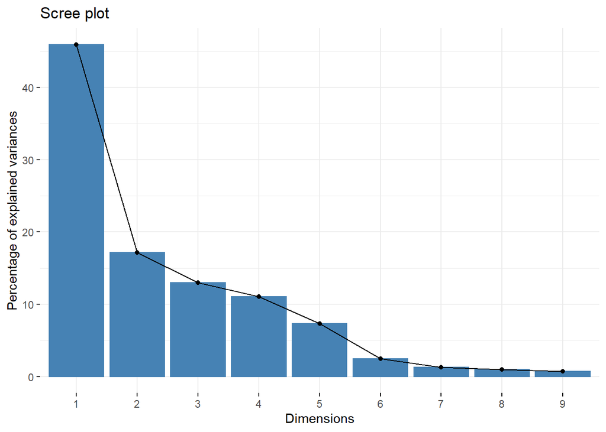

#### PC3 bileşininden sonra sd değerleri 1’in altına düştüğü, scree plot ve plot grafiklerine bakıldığında (dirsek metodu) 3.bileşenden sonra çok büyük bir değişim olmadığı ve PC3 ile verinin total olarak %76’sı açıklanabildiği için burada 3 bileşen seçilmiştir ve analize 3 bileşen üzerinden devam edilmiştir.

# Temel Bileşenlerin Yorumlanması

```
## Importance of components:
##                           PC1    PC2    PC3    PC4    PC5     PC6    PC7
## Standard deviation     2.0336 1.2435 1.0818 0.9974 0.8128 0.47284 0.3368
## Proportion of Variance 0.4595 0.1718 0.1300 0.1105 0.0734 0.02484 0.0126
## Cumulative Proportion  0.4595 0.6313 0.7614 0.8719 0.9453 0.97015 0.9828
##                            PC8     PC9
## Standard deviation     0.29718 0.25860
## Proportion of Variance 0.00981 0.00743
## Cumulative Proportion  0.99257 1.00000
```

```
##                   PC1          PC2         PC3          PC4         PC5
## child_mort -0.4195194 -0.192883937  0.02954353 -0.370653262  0.16896968
## exports     0.2838970 -0.613163494 -0.14476069 -0.003091019 -0.05761584
## health      0.1508378  0.243086779  0.59663237 -0.461897497 -0.51800037
## imports     0.1614824 -0.671820644  0.29992674  0.071907461 -0.25537642
## income      0.3984411 -0.022535530 -0.30154750 -0.392159039  0.24714960
## inflation  -0.1931729  0.008404473 -0.64251951 -0.150441762 -0.71486910
## life_expec  0.4258394  0.222706743 -0.11391854  0.203797235 -0.10821980
## total_fer  -0.4037290 -0.155233106 -0.01954925 -0.378303645  0.13526221
## gdpp        0.3926448  0.046022396 -0.12297749 -0.531994575  0.18016662
##                     PC6         PC7         PC8         PC9
## child_mort -0.200628153  0.07948854  0.68274306  0.32754180
## exports     0.059332832  0.70730269  0.01419742 -0.12308207
## health     -0.007276456  0.24983051 -0.07249683  0.11308797
## imports     0.030031537 -0.59218953  0.02894642  0.09903717
## income     -0.160346990 -0.09556237 -0.35262369  0.61298247
## inflation  -0.066285372 -0.10463252  0.01153775 -0.02523614
## life_expec  0.601126516 -0.01848639  0.50466425  0.29403981
## total_fer   0.750688748 -0.02882643 -0.29335267 -0.02633585
## gdpp       -0.016778761 -0.24299776  0.24969636 -0.62564572
```

#### Özvektör değerlerine göre artık verinin boyut indirgenmiş halinde PC1 bileşeni *child_mort*,*life_expec*, *total_fer* ve *income* değişkenlerini temsil ederken PC2 *imports* ve *exports*, PC3 ise *inflation* ve *health* değişkenlerini temsil ediyor. PC1->life_quality, PC2->trade, PC3<-financial_status

# Ülkelerin özelliklerine göre konumları

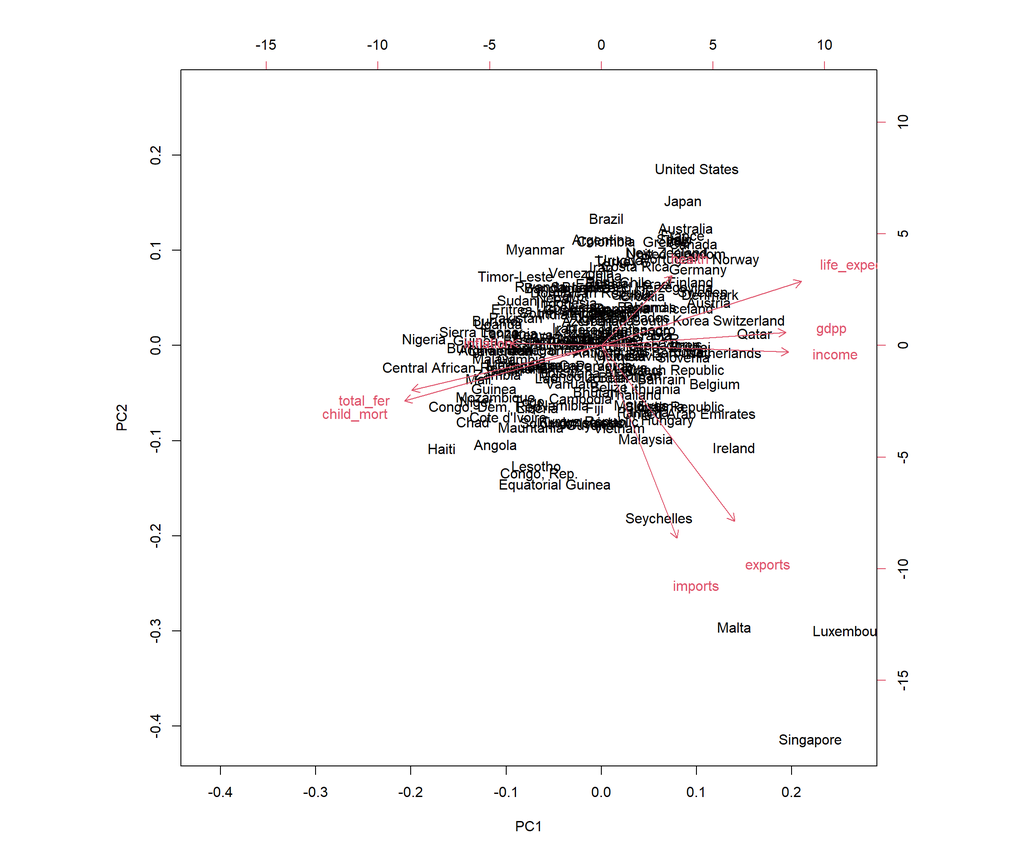

# Singapur

```r
data.pca$x ["Singapore",1:3]
```

```
##        PC1        PC2        PC3
##  5.7660348 -6.6620540 -0.6524578
```

#### Yukarıdaki grafikte bileşenler bazında değişkenlerin ve eyaletlerin konumları gösterilmiştir. Singapur’un konumuna bakıldığında PC1 (life_quality) açısından pozitif PC2 (trade) açısından negatif konumda yer almaktadır ve en yüksek temsil edilme oranı 2.bileşen ile olmuştur. Singapur export ve import değişkenleri ile aynı tarafta bulunduğu için ithalat ve ihracat değerlerinin yüksek olduğu söylenebilir. Aynı şekilde life_exp ve income değişkenleri ile de aynı tarafta bulunduğundan oratlama yaşam beklentisi ve gelir açısından yüksek bir şehirken çocuk ölümleri(chil_mort) ve doğacak çocuk sayısı (total_fer) bakımından düşüktür.

# Singapur

```
## # A tibble: 1 x 9
##   child_mort exports health imports income inflation life_expec total_fer  gdpp
##        <dbl>   <dbl>  <dbl>   <dbl>  <dbl>     <dbl>      <dbl>     <dbl> <dbl>
## 1        2.8     200   3.96     174  72100    -0.046       82.7      1.15 46600
```

```
##    child_mort        exports            health          imports
##  Min.   :  2.60   Min.   :  0.109   Min.   : 1.810   Min.   :  0.0659
##  1st Qu.:  8.25   1st Qu.: 23.800   1st Qu.: 4.920   1st Qu.: 30.2000
##  Median : 19.30   Median : 35.000   Median : 6.320   Median : 43.3000
##  Mean   : 38.27   Mean   : 41.109   Mean   : 6.816   Mean   : 46.8902
##  3rd Qu.: 62.10   3rd Qu.: 51.350   3rd Qu.: 8.600   3rd Qu.: 58.7500
##  Max.   :208.00   Max.   :200.000   Max.   :17.900   Max.   :174.0000
##      income         inflation         life_expec      total_fer
##  Min.   :   609   Min.   : -4.210   Min.   :32.10   Min.   :1.150
##  1st Qu.:  3355   1st Qu.:  1.810   1st Qu.:65.30   1st Qu.:1.795
##  Median :  9960   Median :  5.390   Median :73.10   Median :2.410
##  Mean   : 17145   Mean   :  7.782   Mean   :70.56   Mean   :2.948
##  3rd Qu.: 22800   3rd Qu.: 10.750   3rd Qu.:76.80   3rd Qu.:3.880
##  Max.   :125000   Max.   :104.000   Max.   :82.80   Max.   :7.490
##       gdpp
##  Min.   :   231
##  1st Qu.:  1330
##  Median :  4660
##  Mean   : 12964
##  3rd Qu.: 14050
##  Max.   :105000
```

#### Malta ve Luxembourg içinde benzer yorumlar yapılabilir.

# Nijerya

```r
data["Nigeria",]
```

```
## # A tibble: 1 x 9
##   child_mort exports health imports income inflation life_expec total_fer  gdpp
##        <dbl>   <dbl>  <dbl>   <dbl>  <dbl>     <dbl>      <dbl>     <dbl> <dbl>
## 1        130    25.3   5.07    17.4   5150       104       60.5      5.84  2330
```

```r
data.pca$x["Nigeria",1:3]
```

```
##         PC1         PC2         PC3
## -4.89733728  0.09421533 -6.09183691
```

```r
summary(data)
```

```
##    child_mort        exports            health          imports
##  Min.   :  2.60   Min.   :  0.109   Min.   : 1.810   Min.   :  0.0659
##  1st Qu.:  8.25   1st Qu.: 23.800   1st Qu.: 4.920   1st Qu.: 30.2000
##  Median : 19.30   Median : 35.000   Median : 6.320   Median : 43.3000
##  Mean   : 38.27   Mean   : 41.109   Mean   : 6.816   Mean   : 46.8902
##  3rd Qu.: 62.10   3rd Qu.: 51.350   3rd Qu.: 8.600   3rd Qu.: 58.7500
##  Max.   :208.00   Max.   :200.000   Max.   :17.900   Max.   :174.0000
##      income         inflation         life_expec      total_fer
##  Min.   :   609   Min.   : -4.210   Min.   :32.10   Min.   :1.150
##  1st Qu.:  3355   1st Qu.:  1.810   1st Qu.:65.30   1st Qu.:1.795
##  Median :  9960   Median :  5.390   Median :73.10   Median :2.410
##  Mean   : 17145   Mean   :  7.782   Mean   :70.56   Mean   :2.948
##  3rd Qu.: 22800   3rd Qu.: 10.750   3rd Qu.:76.80   3rd Qu.:3.880
##  Max.   :125000   Max.   :104.000   Max.   :82.80   Max.   :7.490
##       gdpp
##  Min.   :   231
##  1st Qu.:  1330
##  Median :  4660
##  Mean   : 12964
##  3rd Qu.: 14050
##  Max.   :105000
```

#### Nijeraya’ya bakıldığında ise en yüksek 3. bileşen tarafından temsil edildiği görülüyor.(inflation=104>>5 (max değer)) *total_fer* ve *child_mort* değişkenleri bakımından da ortalamadan yüksektir.

```
## # A tibble: 1 x 9
##   child_mort exports health imports income inflation life_expec total_fer  gdpp
##        <dbl>   <dbl>  <dbl>   <dbl>  <dbl>     <dbl>      <dbl>     <dbl> <dbl>
## 1       19.1    20.4   6.74    25.5  18000      7.01       78.2      2.15 10700
```

```
##        PC1        PC2        PC3
##  0.4002340  1.4077559 -0.2250085
```

# Yorum

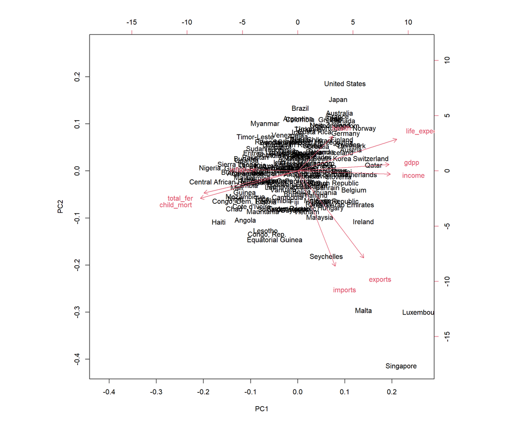

#### –> Yukarıdaki grafiğe bakıldığında Nijerya, Afrika, Haiti gibi sol tarafta kalan ülkeler açısından *doğacak çocuk sayısı* ve *çocuk ölümleri* değişkenlerinin; Norveç, Katar ve İrlanda gibi sağ tarafta konumlanan ülkeler açısından da *yaşam süresi*, *gelir* ve *gysh* değişkenlerinin yüksek değerler aldığı söylenebilir. Benzer olarak; Malta, Lüksemburg ve Singapur gibi ülkelerin *ithalat* ve *ihracat* değişkenlerinin yüksek olduğu söylenebilir.

# Değişkenlerin her bir bileşen tarafından açıklanma oranları

```
##                 Dim.1        Dim.2       Dim.3        Dim.4       Dim.5
## child_mort 0.72786136 0.0575305975 0.001021534 1.366673e-01 0.018861171
## exports    0.33332356 0.5813790019 0.024526152 9.504568e-06 0.002192981
## health     0.09409466 0.0913754315 0.416621553 2.122366e-01 0.177260193
## imports    0.10784378 0.6979325480 0.105283061 5.143716e-03 0.043083667
## income     0.65655748 0.0007853122 0.106424002 1.529866e-01 0.040352543
## inflation  0.15432525 0.0001092264 0.483170891 2.251468e-02 0.337601319
## life_expec 0.74995658 0.0766961382 0.015188572 4.131670e-02 0.007736856
## total_fer  0.67409990 0.0372627974 0.000447289 1.423672e-01 0.012086597
## gdpp       0.63759400 0.0032752557 0.017700248 2.815422e-01 0.021443701
##                   Dim.6        Dim.7        Dim.8        Dim.9
## child_mort 8.999510e-03 7.167544e-04 4.116715e-02 7.174594e-03
## exports    7.870916e-04 5.675080e-02 1.780145e-05 1.013102e-03
## health     1.183791e-05 7.080311e-03 4.641669e-04 8.552570e-04
## imports    2.016463e-04 3.978165e-02 7.399901e-05 6.559342e-04
## income     5.748529e-03 1.035941e-03 1.098144e-02 2.512812e-02
## inflation  9.823597e-04 1.241923e-03 1.175651e-05 4.259019e-05
## life_expec 8.079173e-02 3.876731e-05 2.249269e-02 5.781974e-03
## total_fer  1.259955e-01 9.426338e-05 7.600048e-03 4.638295e-05
## gdpp       6.294408e-05 6.698320e-03 5.506310e-03 2.617706e-02
```

#### Yalnızca PC1 ile çocuk ölümlerinin %72’si temsil edilirken 3 bileşenle birlikte %80’i temsil edilmektedir.

# Değişkenlerin Konumu

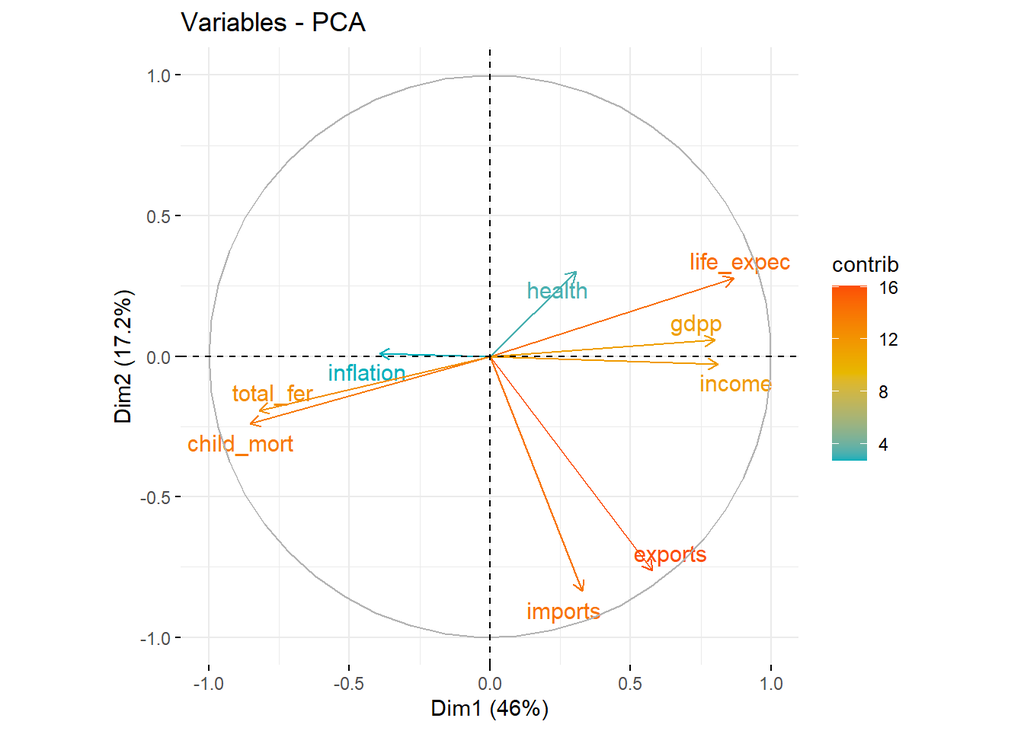

#### *imports* ve *life_expec* değişkenlerinin aralarındakı açı 90 dereceye yakın olduğu için korelasyonlarının çok düşük olduğu söylenebilir. *life_expec* ve *child_mort* arasında yaklaşık 180 dereceli bir açı olduğu için ters yönde ilişkilidir.

#### Benzer yorumlar tanımlayıcı istatistik kısmında korelasyon matrisi üzerinden yapılmıştır. Dim1 boyutunda *child_mort* ve *total_fer* değişkenleri önemliyken Dim2 boyutunda *import* ve *export* değişkenleri önemlidir.

# Uzaklık-Benzerlik Matrisleri

### Scale_Data

```
##    child_mort         exports            health           imports
##  Min.   :-0.8845   Min.   :-1.4957   Min.   :-1.8223   Min.   :-1.9341
##  1st Qu.:-0.7444   1st Qu.:-0.6314   1st Qu.:-0.6901   1st Qu.:-0.6894
##  Median :-0.4704   Median :-0.2229   Median :-0.1805   Median :-0.1483
##  Mean   : 0.0000   Mean   : 0.0000   Mean   : 0.0000   Mean   : 0.0000
##  3rd Qu.: 0.5909   3rd Qu.: 0.3736   3rd Qu.: 0.6496   3rd Qu.: 0.4899
##  Max.   : 4.2086   Max.   : 5.7964   Max.   : 4.0353   Max.   : 5.2504
##      income          inflation         life_expec        total_fer
##  Min.   :-0.8577   Min.   :-1.1344   Min.   :-4.3242   Min.   :-1.1877
##  1st Qu.:-0.7153   1st Qu.:-0.5649   1st Qu.:-0.5910   1st Qu.:-0.7616
##  Median :-0.3727   Median :-0.2263   Median : 0.2861   Median :-0.3554
##  Mean   : 0.0000   Mean   : 0.0000   Mean   : 0.0000   Mean   : 0.0000
##  3rd Qu.: 0.2934   3rd Qu.: 0.2808   3rd Qu.: 0.7021   3rd Qu.: 0.6157
##  Max.   : 5.5947   Max.   : 9.1023   Max.   : 1.3768   Max.   : 3.0003
##       gdpp
##  Min.   :-0.69471
##  1st Qu.:-0.63475
##  Median :-0.45307
##  Mean   : 0.00000
##  3rd Qu.: 0.05924
##  Max.   : 5.02140
```

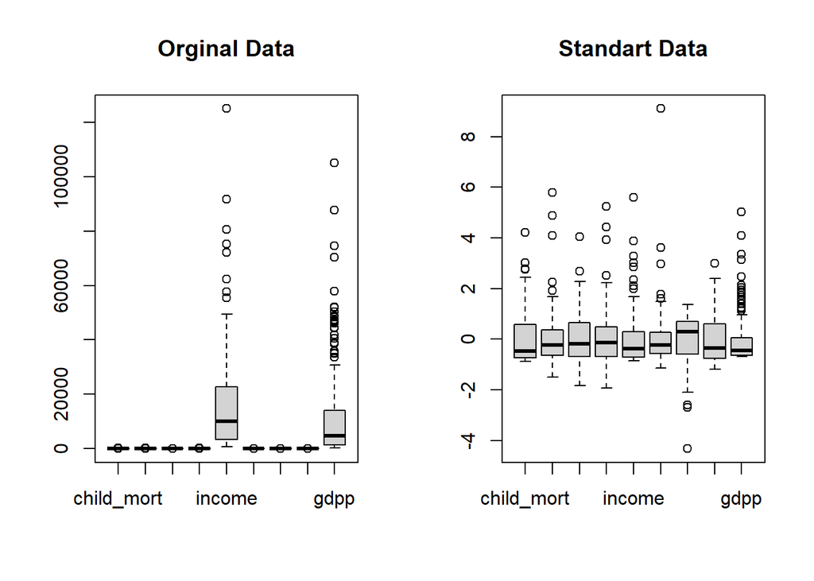

#### Verilerin standartlaştırıldıktan sonraki kutu grafiklerine bakıldığında uç ve aykırı değerlere sahip olduğu görülmektedir.

# Yöntemler

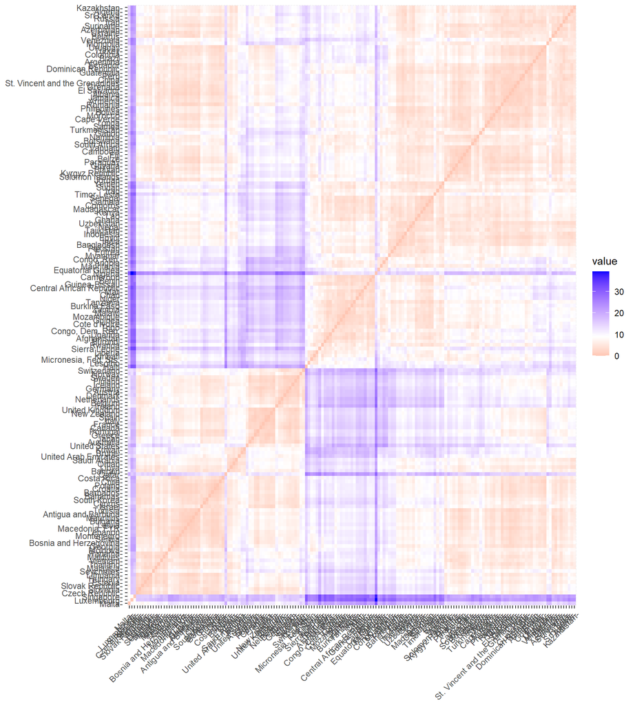

```r
dist_man=dist(data_scale, method="manhattan")
View(round(as.matrix(dist_man)))
fviz_dist(dist_man)
```

# Karşılaştırma

```r
round(as.matrix(dist_eucl)[1:10, 1:10], 2)
```

```
##                     Afghanistan Albania Algeria Angola Antigua and Barbuda
## Afghanistan                0.00    4.13    3.89   2.99                4.40
## Albania                    4.13    0.00    1.84   5.00                1.12
## Algeria                    3.89    1.84    0.00   3.87                2.11
## Angola                     2.99    5.00    3.87   0.00                4.97
## Antigua and Barbuda        4.40    1.12    2.11   4.97                0.00
## Argentina                  4.17    2.28    1.89   4.91                2.85
## Armenia                    3.99    0.97    1.51   4.66                1.66
## Australia                  5.79    3.48    3.92   6.64                3.27
## Austria                    5.99    3.50    4.27   6.75                3.01
## Azerbaijan                 3.89    2.05    1.48   3.98                2.32
##                     Argentina Armenia Australia Austria Azerbaijan
## Afghanistan              4.17    3.99      5.79    5.99       3.89
## Albania                  2.28    0.97      3.48    3.50       2.05
## Algeria                  1.89    1.51      3.92    4.27       1.48
## Angola                   4.91    4.66      6.64    6.75       3.98
## Antigua and Barbuda      2.85    1.66      3.27    3.01       2.32
## Argentina                0.00    2.38      3.28    3.76       1.98
## Armenia                  2.38    0.00      3.91    4.18       1.98
## Australia                3.28    3.91      0.00    1.86       3.87
## Austria                  3.76    4.18      1.86    0.00       3.97
## Azerbaijan               1.98    1.98      3.87    3.97       0.00
```

```r
round(as.matrix(dist_man)[1:10, 1:10], 2)
```

```
##                     Afghanistan Albania Algeria Angola Antigua and Barbuda
## Afghanistan                0.00    9.12   10.04   6.70               11.47
## Albania                    9.12    0.00    4.34  12.11                2.99
## Algeria                   10.04    4.34    0.00   9.12                5.16
## Angola                     6.70   12.11    9.12   0.00               12.81
## Antigua and Barbuda       11.47    2.99    5.16  12.81                0.00
## Argentina                 10.57    5.17    4.59  12.64                5.84
## Armenia                    8.57    2.11    3.86  10.56                4.67
## Australia                 15.00    7.91   10.06  19.18                7.69
## Austria                   16.12    7.82   10.94  18.16                6.70
## Azerbaijan                 9.97    5.20    3.87   9.57                5.35
##                     Argentina Armenia Australia Austria Azerbaijan
## Afghanistan             10.57    8.57     15.00   16.12       9.97
## Albania                  5.17    2.11      7.91    7.82       5.20
## Algeria                  4.59    3.86     10.06   10.94       3.87
## Angola                  12.64   10.56     19.18   18.16       9.57
## Antigua and Barbuda      5.84    4.67      7.69    6.70       5.35
## Argentina                0.00    5.70      7.01   10.11       5.01
## Armenia                  5.70    0.00      9.17    9.86       5.12
## Australia                7.01    9.17      0.00    3.98       9.64
## Austria                 10.11    9.86      3.98    0.00      10.43
## Azerbaijan               5.01    5.12      9.64   10.43       0.00
```

```r
round(as.matrix(dist.cor)[1:10, 1:10], 1)
```

```
##                     Afghanistan Albania Algeria Angola Antigua and Barbuda
## Afghanistan                 0.0     1.6     1.2    0.3                 1.8
## Albania                     1.6     0.0     0.8    1.7                 0.3
## Algeria                     1.2     0.8     0.0    0.7                 1.0
## Angola                      0.3     1.7     0.7    0.0                 1.7
## Antigua and Barbuda         1.8     0.3     1.0    1.7                 0.0
## Argentina                   1.2     0.7     0.5    1.2                 1.2
## Armenia                     1.4     0.3     0.4    1.2                 0.5
## Australia                   1.5     0.7     1.1    1.7                 0.7
## Austria                     1.7     0.6     1.3    1.9                 0.5
## Azerbaijan                  1.3     1.1     0.5    0.8                 1.3
##                     Argentina Armenia Australia Austria Azerbaijan
## Afghanistan               1.2     1.4       1.5     1.7        1.3
## Albania                   0.7     0.3       0.7     0.6        1.1
## Algeria                   0.5     0.4       1.1     1.3        0.5
## Angola                    1.2     1.2       1.7     1.9        0.8
## Antigua and Barbuda       1.2     0.5       0.7     0.5        1.3
## Argentina                 0.0     0.7       0.6     0.8        0.5
## Armenia                   0.7     0.0       1.0     1.0        1.0
## Australia                 0.6     1.0       0.0     0.1        1.0
## Austria                   0.8     1.0       0.1     0.0        1.1
## Azerbaijan                0.5     1.0       1.0     1.1        0.0
```

# Uzaklık matrisine göre birbirine en yakın ve uzak ülkeler:

```
##                    Dominican Republic Ecuador
## Denmark                          9.89    8.97
## Dominican Republic               0.00    1.73
```

```
##         Finland France
## Georgia    7.22   7.65
## Germany    1.78   1.89
```

#### -Dominican-Ecuador->>1.73

#### -Germany-Finland->>1.78

#### -Germany-France->>1.89

#### Yukarıdaki grafiklerde de görüldüğü üzere Almanya ve Fransa değişkenlerin aldığı değerler açısından benzerdir.

# Uzaklık matrisine göre birbirine en yakın ve uzak ülkeler:

```
##           Iraq Ireland
## Guatemala 3.92   13.73
## Guinea    6.17   20.04
```

```
##         Ireland Israel
## Haiti     21.99  16.52
## Hungary    6.78   6.99
```

```
##         Iceland India
## Haiti     18.82 11.40
## Hungary    7.44 10.73
```

#### Haiti-Ireland->>21.99

#### Guinea-Ireland->>20.04

#### Haiti-Iceland->>18.82

#### Haiti ve İrlanda ise birbirlerinden oldukça farklı değişken değerleri almıştır.

# Kümeleme Analizleri

### Bu adımda ülkeleri kümelere ayırmak için optimal küme sayısı dikkate alınarak k-means ve k-medoids algoritmaları denenmiştir. En uygun sonuç veren kümeleme algoritmaları gösterilmiştir.

### K Means

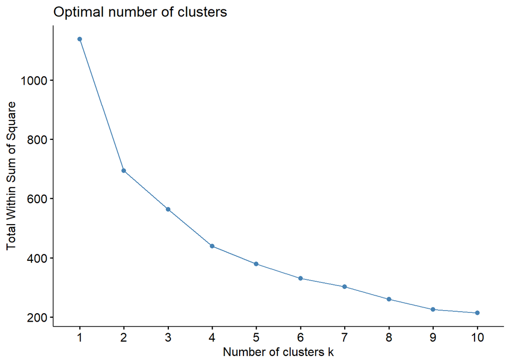

```r
data_pca <- predict(data.pca)[,1:3]
par(mfrow=c(2,2))
fviz_nbclust(data_pca,kmeans,method = "wss")
```

# k=4

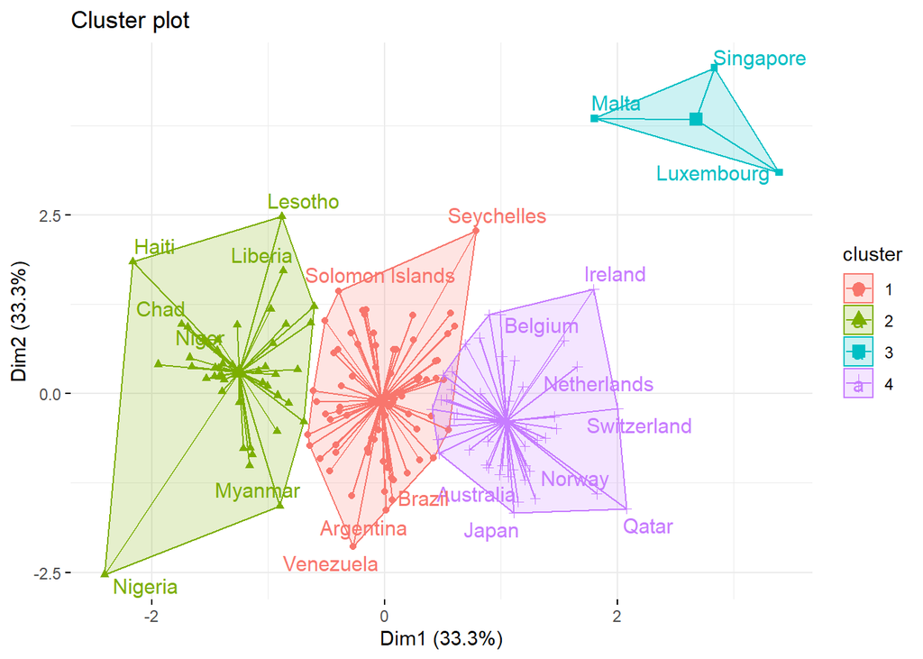

### Küme İçi Değişimler (k=4)

```
##   Group.1         PC1         PC2         PC3
## 1       1 -0.05905712  0.07087458 -0.10202013
## 2       2 -2.54049140 -0.38738276  0.03778264
## 3       3  5.44385209 -5.41618403 -0.21101332
## 4       4  2.12257947  0.59828829  0.13655475
```

```
##   Group.1       PC1       PC2       PC3
## 1       1 0.7012386 0.9151703 0.8864953
## 2       2 0.8018914 0.8701526 1.3942672
## 3       3 1.6381876 1.0797742 1.0785695
## 4       4 0.8496016 1.0394667 1.0420538
```

# k=5

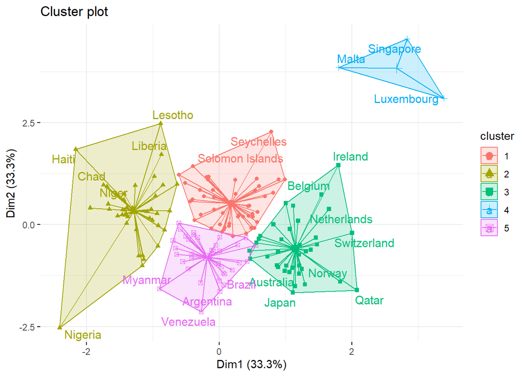

### Küme İçi Değişimler (k=5)

```
##   Group.1        PC1        PC2         PC3
## 1       1  0.3675854 -0.4366505  0.51622730
## 2       2 -2.6169995 -0.4382165  0.04489389
## 3       3  2.3396213  0.7977038 -0.02211162
## 4       4  5.4438521 -5.4161840 -0.21101332
## 5       5 -0.3678986  0.7053043 -0.69417884
```

```
##   Group.1       PC1       PC2       PC3
## 1       1 0.8068726 0.7493958 0.6095472
## 2       2 0.7736871 0.8435375 1.3659558
## 3       3 0.8096534 1.0087014 1.1064586
## 4       4 1.6381876 1.0797742 1.0785695
## 5       5 0.7167716 0.6485578 0.8214862
```

# K Medoids

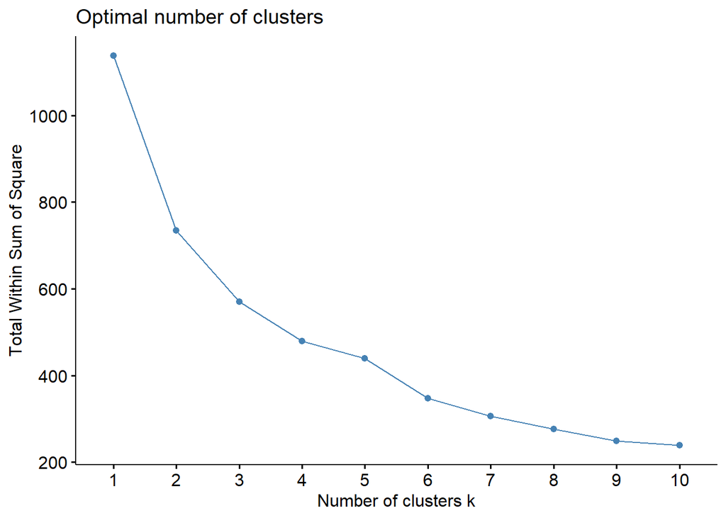

### k=3

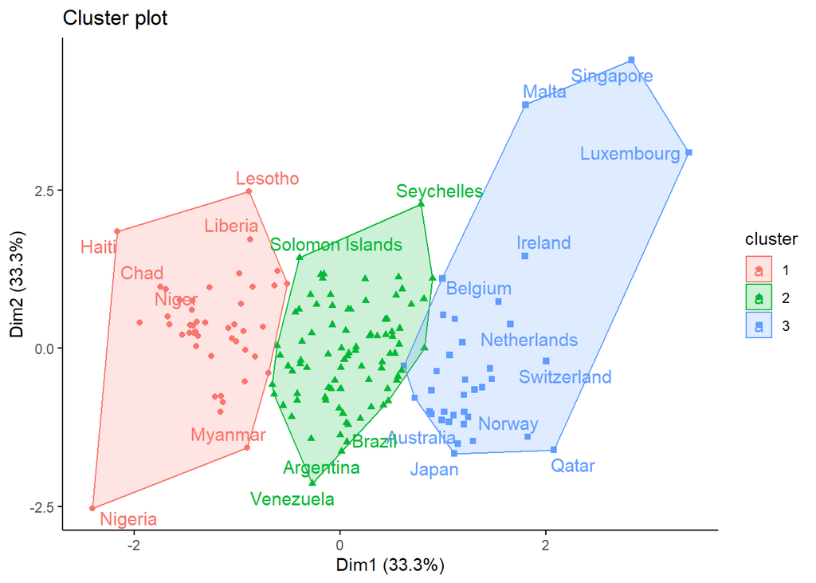

# Küme İçi Değişimler (k=3)

```
##   Group.1        PC1        PC2         PC3
## 1       1 -2.5071526 -0.4009928  0.05317278
## 2       2  0.1605824  0.1068030 -0.01622353
## 3       3  2.7503274  0.2461005 -0.02770976
```

```
##   Group.1       PC1       PC2       PC3
## 1       1 0.8236697 0.8650391 1.3821933
## 2       2 0.8001828 0.8968152 0.8726455
## 3       3 1.1319895 2.0354564 1.1378878
```

# SONUÇ

#### Veri ve çalışmanın amacı doğrultusunda PCA ile boyut küçültülmüş 4 kümeli k_means veya 3 kümeli k_medoids algoritmaları da ikinci ve üçüncü seçenek olarak değerlendirilebilir.

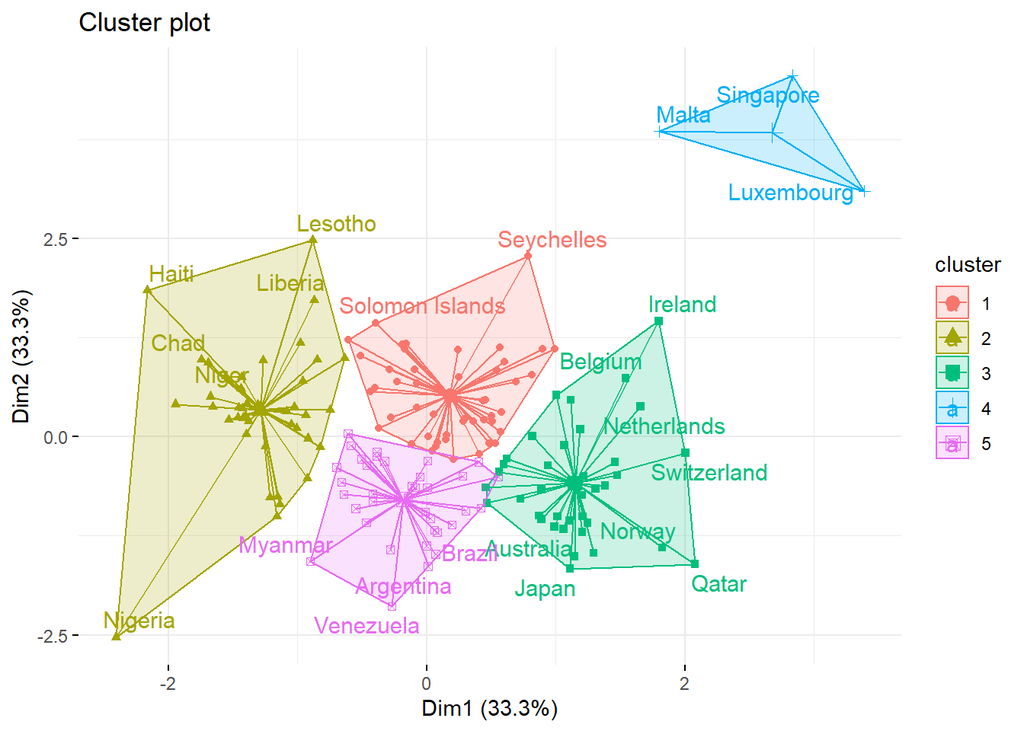